# Chapter 3 exercises

## Question 1

Fitting example data

### a) fit linear regression, summarize inference

### b) plot the results

```r
model1 = lm(y ~ x1 + x2, data = example_data[1:40, ])
summary(model1)
```

```
##
## Call:
## lm(formula = y ~ x1 + x2, data = example_data[1:40, ])
##
## Residuals:
##     Min      1Q  Median      3Q     Max
## -0.9585 -0.5865 -0.3356  0.3973  2.8548
##
## Coefficients:
##             Estimate Std. Error t value Pr(>|t|)
## (Intercept)  1.31513    0.38769   3.392  0.00166 **
## x1           0.51481    0.04590  11.216 1.84e-13 ***
## x2           0.80692    0.02434  33.148  < 2e-16 ***
## ---
## Signif. codes:  0 '***' 0.001 '**' 0.01 '*' 0.05 '.' 0.1 ' ' 1
##
## Residual standard error: 0.9 on 37 degrees of freedom
## Multiple R-squared:  0.9724, Adjusted R-squared:  0.9709
## F-statistic: 652.4 on 2 and 37 DF,  p-value: < 2.2e-16
```

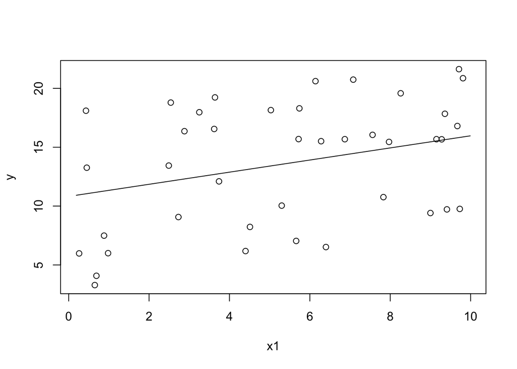

```r
sigma = summary(model1)$sigma


with(example_data, plot(x1, y))
curve(cbind(1, x,  mean(example_data$x2[1:40])) %*% coef(model1), add = T)
```

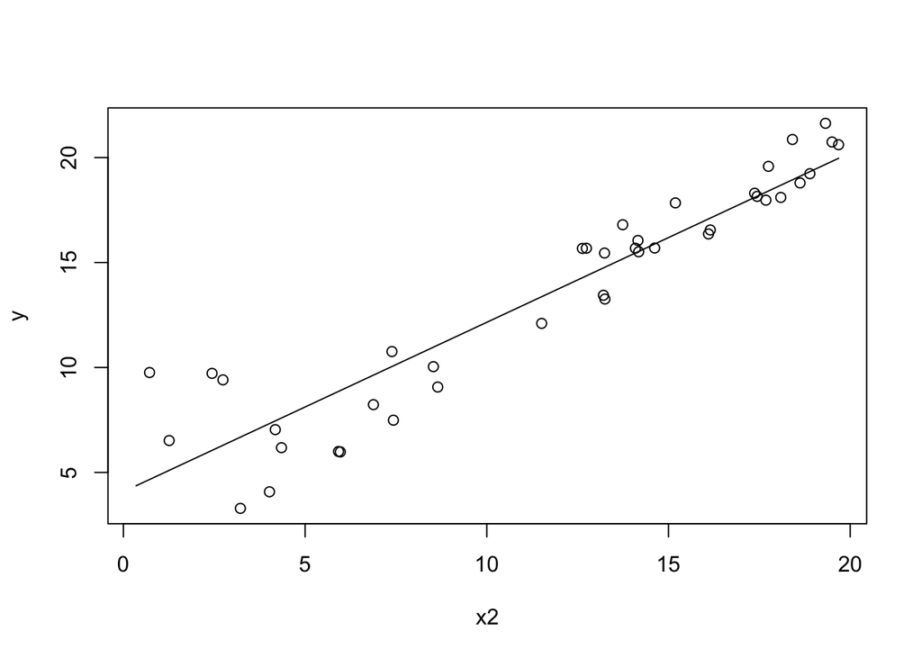

```r
with(example_data, plot(x2, y))
curve(cbind(1, mean(example_data$x1[1:40]), x) %*% coef(model1), add = T)
```

### c) plot residuals

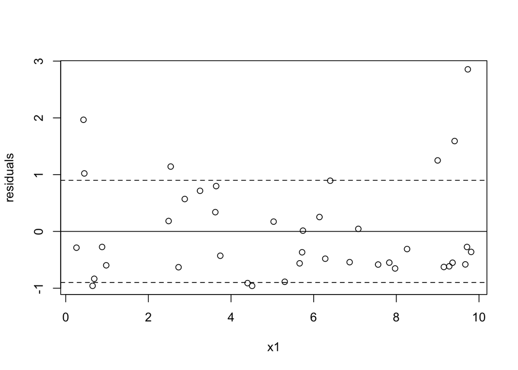

```r
residuals = example_data$y[1:40] - predict(model1, example_data[1:40,])

with(example_data[1:40, ], plot(x1, residuals))
abline(a = 0, b = 0)
abline(a = -sigma, b = 0, lty = 2)
abline(a = sigma, b = 0, lty = 2)
```

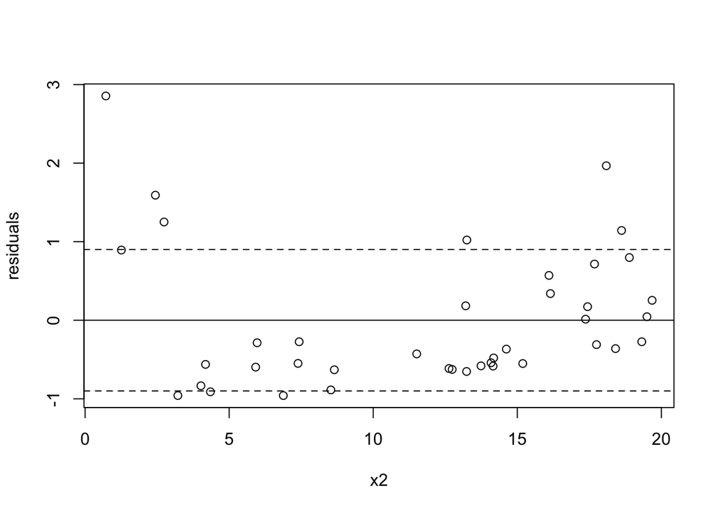

```r
with(example_data[1:40, ], plot(x2, residuals))
abline(a = 0, b = 0)
abline(a = -sigma, b = 0, lty = 2)
abline(a = sigma, b = 0, lty = 2)
```

### d) predict using the remaining 20 data points

The diagnostics aren’t great but the predictions seem ok.

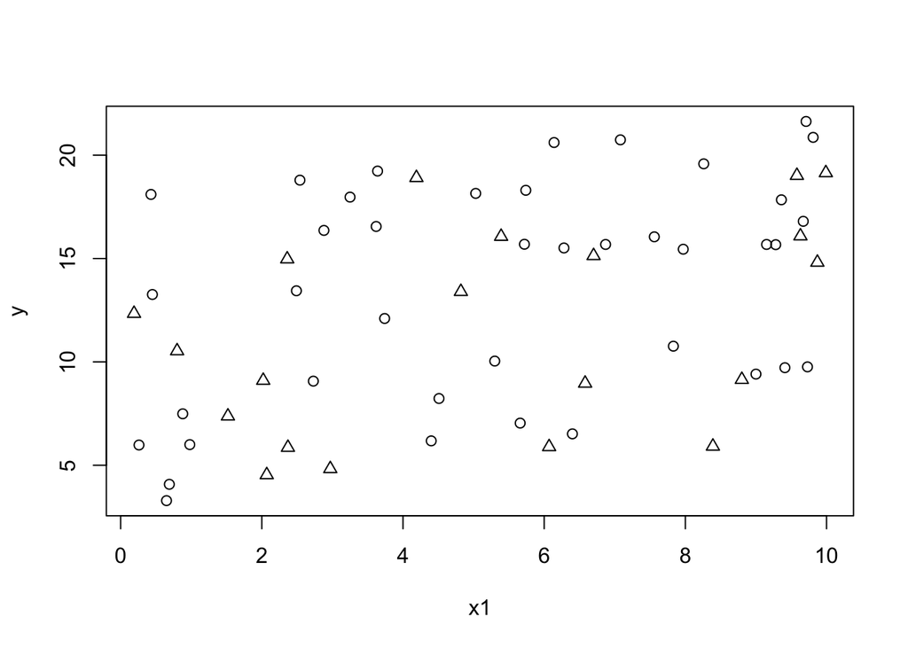

```r
predict_y = predict(model1, example_data[41:60, ])

with(example_data, plot(x1, y))
with(example_data[41:60,], points(x1, predict_y, pch = 2))
```

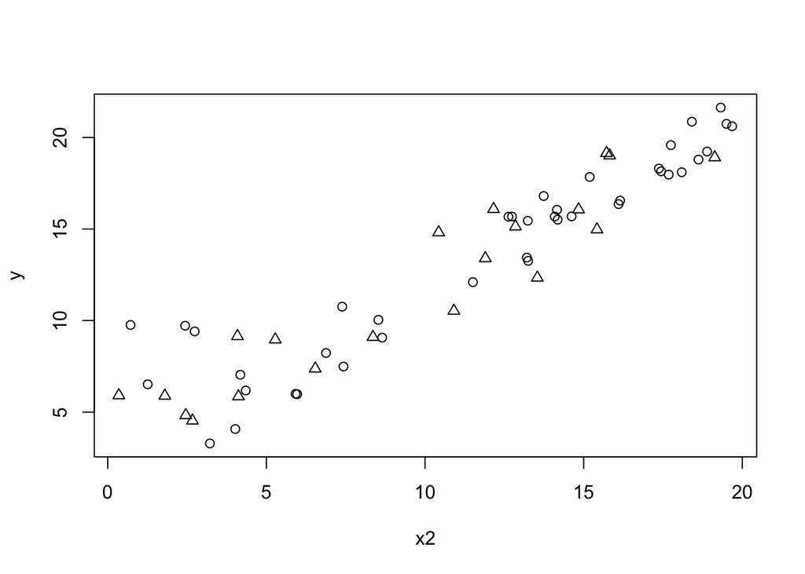

```r
with(example_data, plot(x2, y))
with(example_data[41:60,], points(x2, predict_y, pch = 2))
```

## Question 2

log earnings ~ log height

- 66 inch tall person makes $30K
- 1% height increase = 0.8% increase in earnings
- 95% of predicted earnings fall within a factor of 1.1

### a) give the line and model sd

*First the equation*

Model 2: $Log E2 = log(\$30K) + m * log(H2/66)$  
Model 1: $log E1 = log(\$30K) + m * log(H1/66)$

If there is an 0.8% increase in earnings that means:
$$E2 = 1.008 * E1$$
$$log(E2) - log(E1) \approx 0.008$$

This is per 1% height increase so similarly:
$$log(H2) - log(H1) \approx 0.01$$

So if you do model 2 - model 1:
$$log(E2) - log(E1) = m * (log(H2) - log(H1))$$
$$0.008 = m * 0.01$$
$$m = 0.8$$

*now the sd (which I’m not entirely sure about and this is surely wrong)*

$$log(1) +- 1.96 * log(sd) = log(1.1)$$
$$sd = exp(log(1.1)/1.96)$$

### b) suppose sd of log height is 5%, what is R^2

The equation for R-sq: $R^2 = 1 - \sigma/{\sigma_y}^2$

But we are given $\sigma_x$.If we assume that is a typo. 5% tells us that for earnings, the sd is about 1.05. so we end up with:
$$1 - 1.049^2/1.05^2 = 0$$

## Question 3

### a) Generate 1000 N(0,1) for two variables and run the regression

```r
set.seed(5)
var1 = rnorm(1000)
var2 = rnorm(1000)

model3 = lm(var2 ~ var1)
summary(model3)
```

```
##
## Call:
## lm(formula = var2 ~ var1)
##
## Residuals:
##     Min      1Q  Median      3Q     Max
## -3.4265 -0.6601 -0.0003  0.6360  2.7875
##
## Coefficients:
##             Estimate Std. Error t value Pr(>|t|)
## (Intercept)  0.07276    0.03141   2.317   0.0207 *
## var1         0.01781    0.03104   0.574   0.5663
## ---
## Signif. codes:  0 '***' 0.001 '**' 0.01 '*' 0.05 '.' 0.1 ' ' 1
##
## Residual standard error: 0.993 on 998 degrees of freedom
## Multiple R-squared:  0.0003296,  Adjusted R-squared:  -0.0006721
## F-statistic: 0.3291 on 1 and 998 DF,  p-value: 0.5663
```

### b) repeat this 100 times, save z, how many z > 2

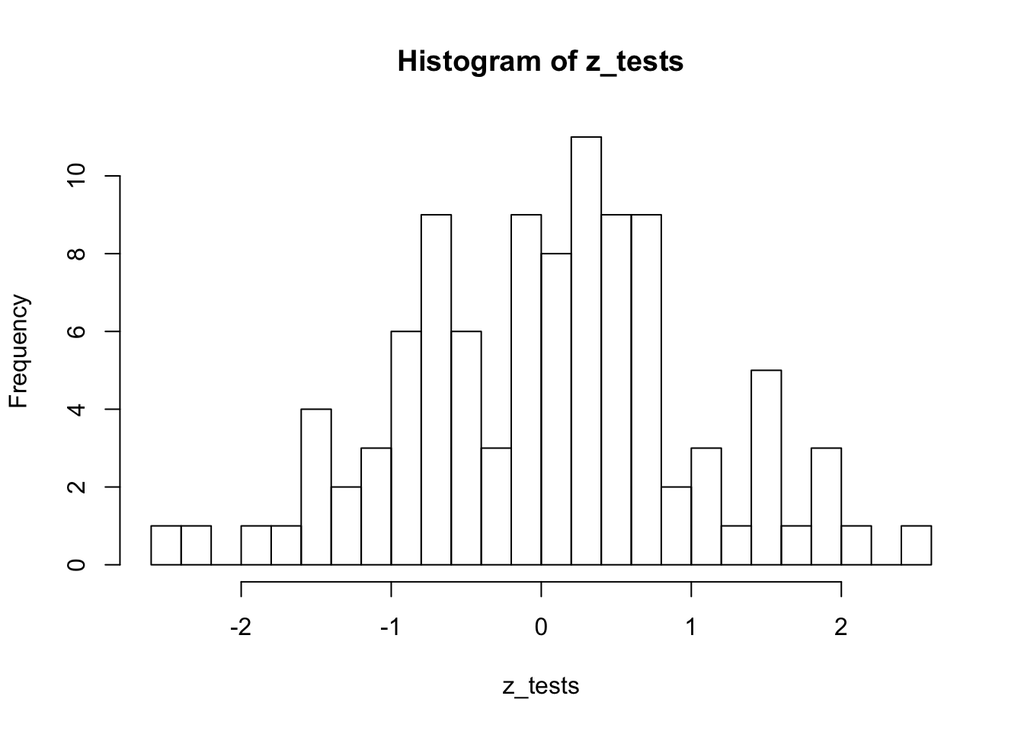

```r
set.seed(150)
z_tests = rep(NA, 100)
for(i in 1:100){
  var1 = rnorm(1000)
  var2 = rnorm(1000)
  fit = lm(var2 ~ var1)
  z_tests[i] = coef(fit)[2]/coef(summary(fit))[2,2]
}
hist(z_tests, breaks = 20)
```

```r
mean(abs(z_tests) > 2)
```

```
## [1] 0.04
```

## Question 4

Load the child iq data. it has age 3 IQ scores with moms age at childs birth and moms education for 400 ids.

```r
library(foreign)
iq.data = read.dta("ARM_Data/child.iq/child.iq.dta")
```

### a) Fit IQ on age, plot it, check assumptions and interpret the slope.

```r
model_q4 = lm(ppvt ~ momage, data = iq.data)
summary(model_q4)
```

```
##
## Call:
## lm(formula = ppvt ~ momage, data = iq.data)
##
## Residuals:
##     Min      1Q  Median      3Q     Max
## -67.109 -11.798   2.971  14.860  55.210
##
## Coefficients:
##             Estimate Std. Error t value Pr(>|t|)
## (Intercept)  67.7827     8.6880   7.802 5.42e-14 ***
## momage        0.8403     0.3786   2.219    0.027 *
## ---
## Signif. codes:  0 '***' 0.001 '**' 0.01 '*' 0.05 '.' 0.1 ' ' 1
##
## Residual standard error: 20.34 on 398 degrees of freedom
## Multiple R-squared:  0.01223,    Adjusted R-squared:  0.009743
## F-statistic: 4.926 on 1 and 398 DF,  p-value: 0.02702
```

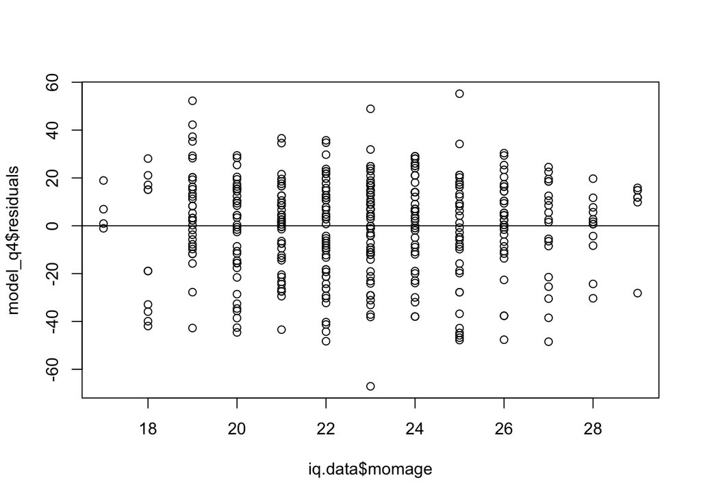

```r
plot(iq.data$momage, model_q4$residuals);abline(0,0)
```

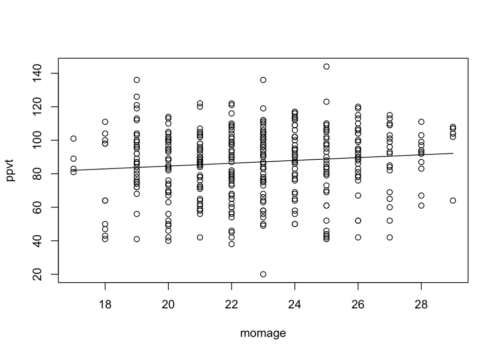

```r
with(iq.data, plot(momage, ppvt))
curve(coef(model_q4)[1] + coef(model_q4)[2] * x, add = T)
```

Child’s IQ increases 0.84 on average per year increase in mom’s age at child’s birth. The model fit is poor but the effect is signficant.

### b) Add in education.

```r
model_q4b = lm(ppvt ~ momage + educ_cat, data = iq.data)
summary(model_q4b)
```

```
##
## Call:
## lm(formula = ppvt ~ momage + educ_cat, data = iq.data)
##
## Residuals:
##     Min      1Q  Median      3Q     Max
## -61.763 -13.130   2.495  14.620  55.610
##
## Coefficients:
##             Estimate Std. Error t value Pr(>|t|)
## (Intercept)  69.1554     8.5706   8.069 8.51e-15 ***
## momage        0.3433     0.3981   0.862 0.389003
## educ_cat      4.7114     1.3165   3.579 0.000388 ***
## ---
## Signif. codes:  0 '***' 0.001 '**' 0.01 '*' 0.05 '.' 0.1 ' ' 1
##
## Residual standard error: 20.05 on 397 degrees of freedom
## Multiple R-squared:  0.04309,    Adjusted R-squared:  0.03827
## F-statistic: 8.939 on 2 and 397 DF,  p-value: 0.0001594
```

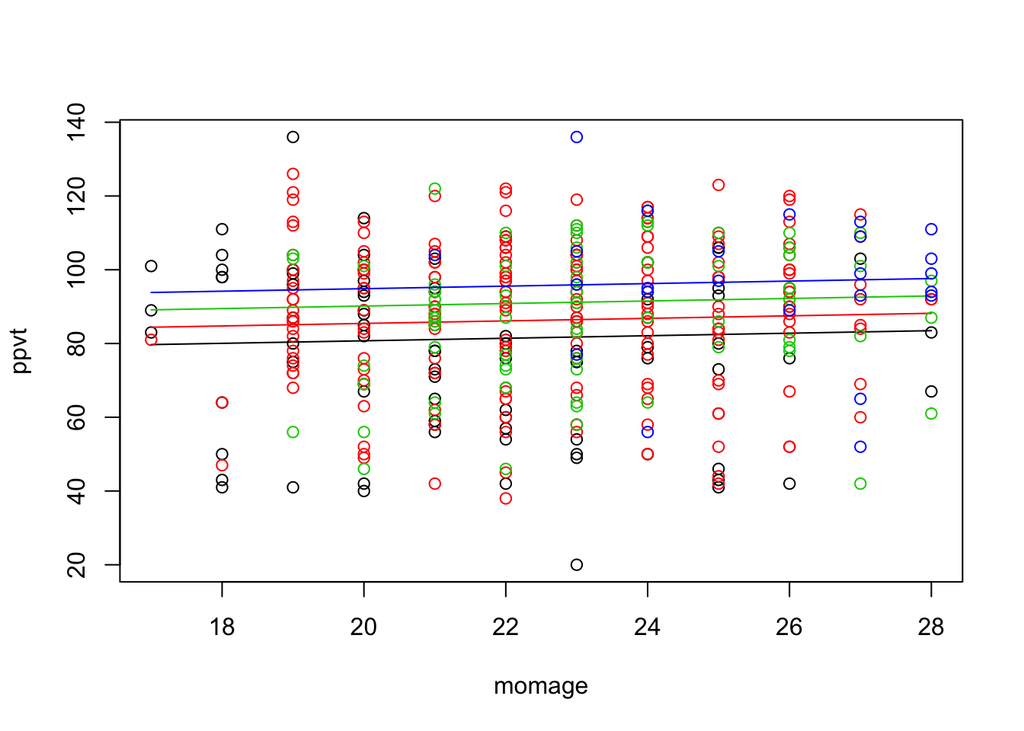

```r
with(subset(iq.data, educ_cat == 1), plot(momage, ppvt))
curve(cbind(1, x, 1) %*% coef(model_q4b), add = T)
for(i in 2:4){
  with(subset(iq.data, educ_cat == i), points(momage, ppvt, col = i))
  curve(cbind(1, x, i) %*% coef(model_q4b), add = T, col = i)
}
```

For a given mom’s age, IQ increases by 4.7 points per increase in education category. For a given education category, IQ increases by 0.34 per year increase in mom’s age (not significant).

### c) Make a new variable for whether mom completes high school. Add an interaction.

```r
iq.data$mom_posths = with(iq.data, ifelse(educ_cat > 1, 1, 0))

model_q4c = lm(ppvt ~ momage * mom_posths, data = iq.data)
summary(model_q4c)
```

```
##
## Call:
## lm(formula = ppvt ~ momage * mom_posths, data = iq.data)
##
## Residuals:
##     Min      1Q  Median      3Q     Max
## -56.696 -12.407   2.022  14.804  54.343
##
## Coefficients:
##                   Estimate Std. Error t value Pr(>|t|)
## (Intercept)       105.2202    17.6454   5.963 5.49e-09 ***
## momage             -1.2402     0.8113  -1.529   0.1271
## mom_posths        -38.4088    20.2815  -1.894   0.0590 .
## momage:mom_posths   2.2097     0.9181   2.407   0.0165 *
## ---
## Signif. codes:  0 '***' 0.001 '**' 0.01 '*' 0.05 '.' 0.1 ' ' 1
##
## Residual standard error: 19.85 on 396 degrees of freedom
## Multiple R-squared:  0.06417,    Adjusted R-squared:  0.05708
## F-statistic: 9.051 on 3 and 396 DF,  p-value: 8.276e-06
```

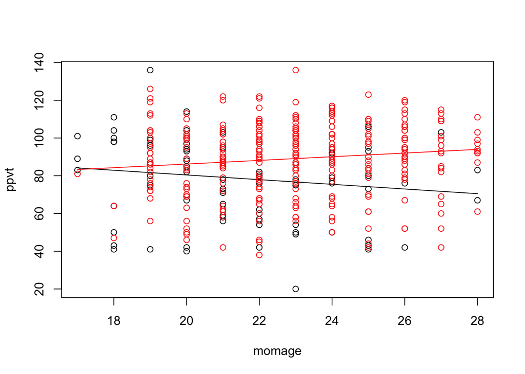

```r
with(subset(iq.data, mom_posths == 0), plot(momage, ppvt))
curve(cbind(1, x, 0, 0) %*% coef(model_q4c), add = T)

with(subset(iq.data, mom_posths == 1), points(momage, ppvt, col = 2))
curve(cbind(1, x, 1, x) %*% coef(model_q4c), add = T, col = 2)
```

### d) Repeat model b for first 200, predict next 200, compare

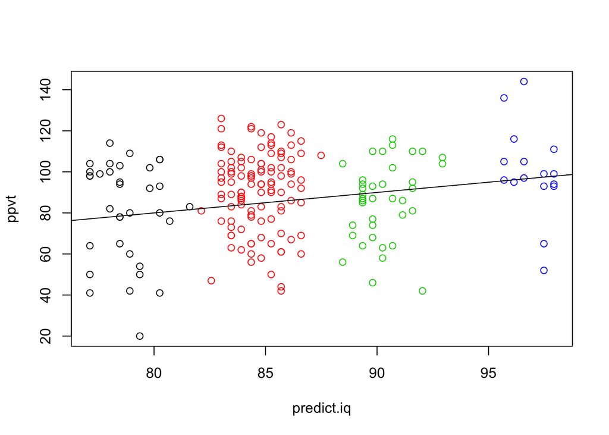

```r
train_data = iq.data[1:200, ]
model_q4d = lm(ppvt ~ momage + educ_cat, data = train_data)

predict_data = iq.data[201:400,]
predict_data$predict.iq = predict(model_q4d, predict_data)

with(predict_data, plot(y = ppvt, x = predict.iq, "n"))
for(i in 1:4){
  with(predict_data,
     points(y = ppvt[educ_cat == i], x = predict.iq[educ_cat == i], col = i))
}
abline(0, 1)
```

## Question 5

Using the beauty data, student evaluation of instructors beauty and teaching quality for courses at UTexas. Evaluations come at end of course, beauty scores come from non-students (at a later time).

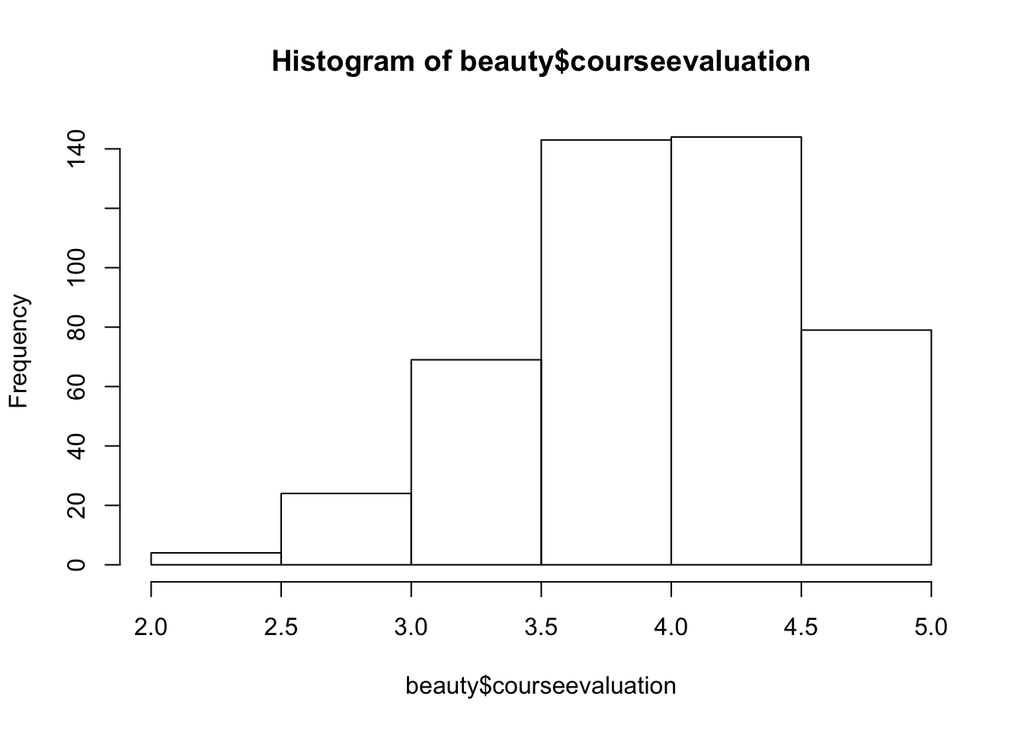

```r
beauty = readr::read_csv("http://www.stat.columbia.edu/~gelman/arm/examples/beauty/ProfEvaltnsBeautyPublic.csv")

hist(beauty$courseevaluation)
```

### a) fit a model testng if beauty predicts outcome.

```r
beauty_model = lm(courseevaluation ~ female + btystdave + age + minority + nonenglish + students + tenured, data = beauty)

summary(beauty_model)
```

```
##
## Call:
## lm(formula = courseevaluation ~ female + btystdave + age + minority +
##     nonenglish + students + tenured, data = beauty)
##
## Residuals:
##      Min       1Q   Median       3Q      Max
## -1.86870 -0.34054  0.04676  0.40210  1.03771
##
## Coefficients:
##               Estimate Std. Error t value Pr(>|t|)
## (Intercept)  4.2672419  0.1454282  29.343  < 2e-16 ***
## female      -0.2291200  0.0535199  -4.281 2.27e-05 ***
## btystdave    0.1425031  0.0331322   4.301 2.08e-05 ***
## age         -0.0013630  0.0029061  -0.469  0.63929
## minority    -0.0545700  0.0757474  -0.720  0.47164
## nonenglish  -0.3327110  0.1087988  -3.058  0.00236 **
## students    -0.0003672  0.0003415  -1.075  0.28285
## tenured     -0.0842460  0.0560241  -1.504  0.13334
## ---
## Signif. codes:  0 '***' 0.001 '**' 0.01 '*' 0.05 '.' 0.1 ' ' 1
##
## Residual standard error: 0.5312 on 455 degrees of freedom
## Multiple R-squared:  0.09734,    Adjusted R-squared:  0.08346
## F-statistic:  7.01 on 7 and 455 DF,  p-value: 5.967e-08
```

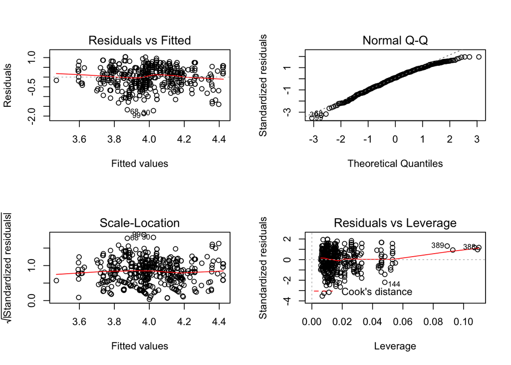

```r
par(mfrow = c(2,2))
plot(beauty_model)
```

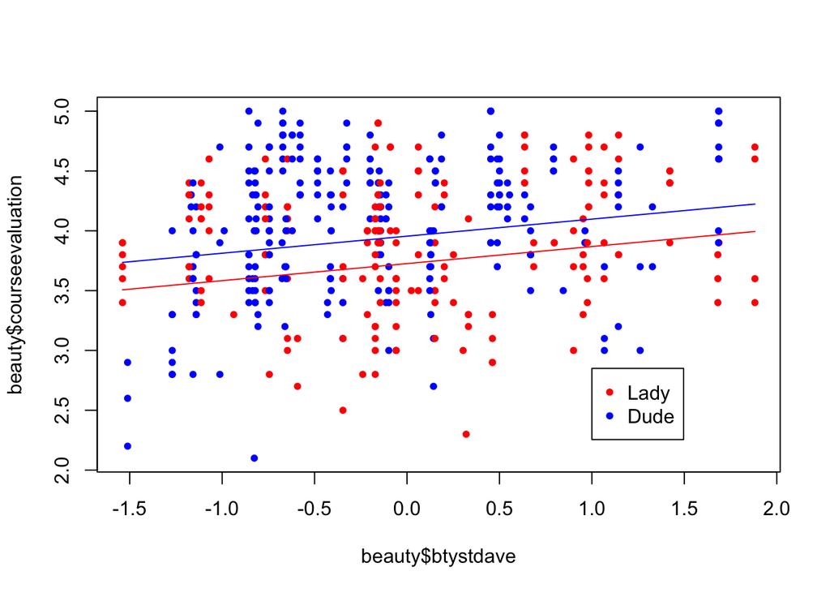

```r
par(mfrow = c(1,1))

colors <- ifelse(beauty$female == 1, "red", "blue")
plot(beauty$btystdave, beauty$courseevaluation, col = colors, pch = 20)
for(i in 0:1)
  curve(cbind(1, i, x, 48, 0.5, 0.5, 30, 0.5) %*% coef(beauty_model),
        add = T,
        col = data.frame(x = c("blue", "red"), stringsAsFactors = F)$x[i + 1])
legend(1, 2.85, legend = c("Lady", "Dude"), col = unique(colors), pch = 20)
```

### b) mess around with other models

Based on my first model, I dumped a few variable that didn’t seem important. I dichomitimized age. I standardardized student total. Tenure and tenure track have a lot of overlap, basically because tenured == 1 corresponds to tenuretrack. I threw an 3-way interaction in there for fun.

```r
beauty$old = ifelse(beauty$age > 50, 1, 0)
beauty$studentz = with(beauty, (log(students) - mean(students))/sd(students))
beauty$large_class = with(beauty, students > 50)


beauty_model_full = lm(courseevaluation ~ female * btystdave * old + nonenglish + large_class + tenured, data = beauty)

summary(beauty_model_full)
```

```
##
## Call:
## lm(formula = courseevaluation ~ female * btystdave * old + nonenglish +
##     large_class + tenured, data = beauty)
##
## Residuals:
##      Min       1Q   Median       3Q      Max
## -1.79862 -0.30516  0.04477  0.38224  1.11321
##
## Coefficients:
##                        Estimate Std. Error t value Pr(>|t|)
## (Intercept)           4.1886143  0.0521409  80.333  < 2e-16 ***
## female               -0.1796043  0.0638112  -2.815 0.005097 **
## btystdave            -0.0450975  0.0638507  -0.706 0.480368
## old                   0.0443326  0.0686608   0.646 0.518817
## nonenglish           -0.4012355  0.1007372  -3.983 7.93e-05 ***
## large_classTRUE      -0.1814852  0.0538905  -3.368 0.000823 ***
## tenured               0.0008251  0.0569649   0.014 0.988450
## female:btystdave      0.1615007  0.0821046   1.967 0.049793 *
## female:old           -0.1687330  0.1023251  -1.649 0.099845 .
## btystdave:old         0.4508058  0.0855002   5.273 2.09e-07 ***
## female:btystdave:old -0.5934914  0.1392380  -4.262 2.46e-05 ***
## ---
## Signif. codes:  0 '***' 0.001 '**' 0.01 '*' 0.05 '.' 0.1 ' ' 1
##
## Residual standard error: 0.5099 on 452 degrees of freedom
## Multiple R-squared:  0.1738, Adjusted R-squared:  0.1555
## F-statistic: 9.507 on 10 and 452 DF,  p-value: 2.073e-14
```

The model isnt that great ($R^2 = 16%$) but the diagnostics seem ok.

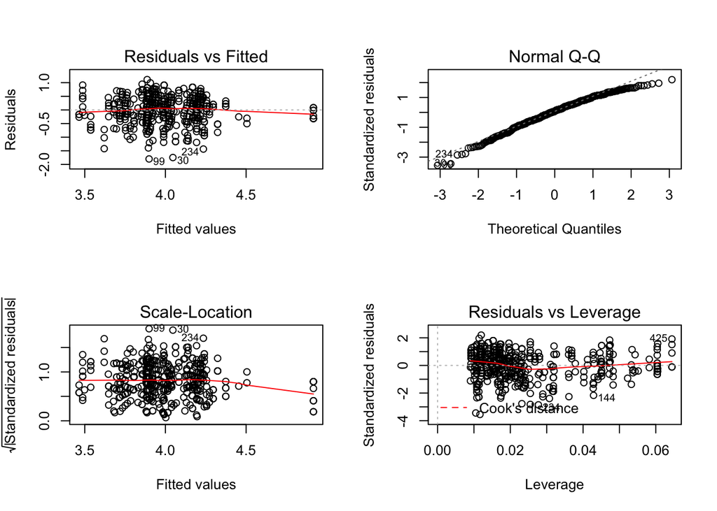

```r
par(mfrow = c(2,2))
plot(beauty_model_full)
```

```r
par(mfrow = c(1,1))
```

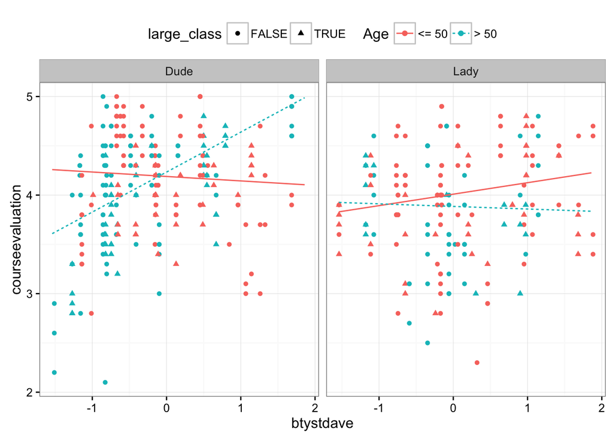

```r
library(ggplot2)
prediction_data = expand.grid(
  btystdave = seq(-1.54, 1.88, by = 0.1),
  female = c(0, 1),
  old = c(0, 1),
  nonenglish = 0,
  large_class  = F,
  tenured = 0.5
)
prediction_data$courseevaluation = predict(beauty_model_full, prediction_data)

ggplot(data = subset(beauty, nonenglish == 0),
       aes(x = btystdave, y = courseevaluation,
                          colour = factor(old), linetype = factor(old),
           shape = large_class)) +
  geom_point() +
  geom_line(data = prediction_data) +
  #geom_smooth(method= "lm") +
  facet_wrap(~female, labeller =
               labeller(female = c("0" = "Dude", "1" = "Lady"),
             nonenglish = c("0" = "English-speaker", "1" = "Non-english-speaker"))) +
  theme_bw() +
  scale_color_discrete("Age", labels = c("<= 50", "> 50")) +
#  scale_shape_discrete("Non-english", labels = c("No", "Yes")) +
  scale_linetype_discrete("Age", labels = c("<= 50", "> 50")) +
  theme(legend.position = "top", legend.box = "horizontal")
```

There are repeat teachers, so lets average their scores.

```r
library(dplyr)
beauty_agg = beauty %>%
  group_by(profnumber, btystdave, female, old, nonenglish, tenured) %>%
  summarize(
    avg_course_rating = mean(courseevaluation),
    pct_large_class = mean(large_class),
    large_class_majority = 1 * (pct_large_class > 0.5)
  )


beauty_model2 = lm(avg_course_rating ~ female * btystdave * old + nonenglish + large_class_majority + tenured, data = beauty_agg)

summary(beauty_model2)
```

```
##
## Call:
## lm(formula = avg_course_rating ~ female * btystdave * old + nonenglish +
##     large_class_majority + tenured, data = beauty_agg)
##
## Residuals:
##      Min       1Q   Median       3Q      Max
## -1.60878 -0.21515  0.05612  0.25875  0.68028
##
## Coefficients:
##                      Estimate Std. Error t value Pr(>|t|)
## (Intercept)           4.10558    0.09939  41.307  < 2e-16 ***
## female               -0.22585    0.11910  -1.896  0.06139 .
## btystdave            -0.07493    0.10339  -0.725  0.47067
## old                   0.11144    0.13086   0.852  0.39690
## nonenglish           -0.44733    0.17026  -2.627  0.01025 *
## large_class_majority -0.10070    0.09674  -1.041  0.30096
## tenured              -0.02774    0.10448  -0.265  0.79128
## female:btystdave      0.16577    0.13828   1.199  0.23401
## female:old           -0.17645    0.18825  -0.937  0.35132
## btystdave:old         0.51823    0.15402   3.365  0.00116 **
## female:btystdave:old -0.60257    0.24601  -2.449  0.01641 *
## ---
## Signif. codes:  0 '***' 0.001 '**' 0.01 '*' 0.05 '.' 0.1 ' ' 1
##
## Residual standard error: 0.4196 on 83 degrees of freedom
## Multiple R-squared:  0.2611, Adjusted R-squared:  0.1721
## F-statistic: 2.933 on 10 and 83 DF,  p-value: 0.003382
```

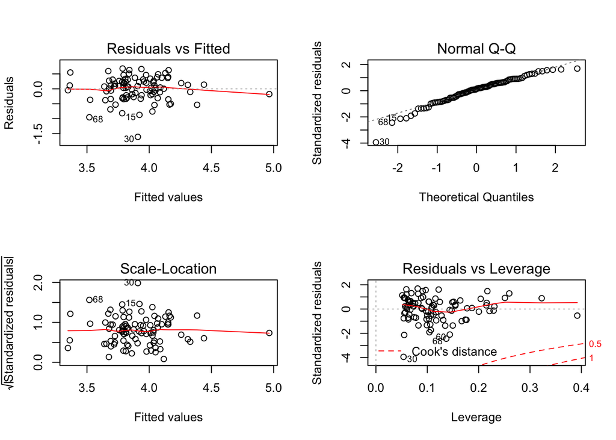

```r
par(mfrow = c(2,2))
plot(beauty_model2)
```

```r
par(mfrow = c(1,1))
```

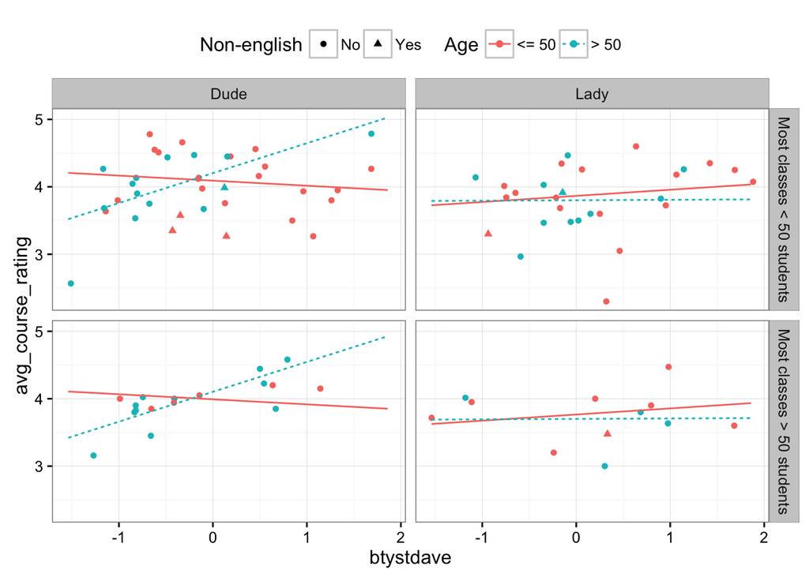

```r
prediction_data2 = expand.grid(
  btystdave = seq(-1.54, 1.88, by = 0.1),
  female = c(0, 1),
  old = c(0, 1),
  nonenglish = 0,
  large_class_majority  = c(0,1),
  tenured = 0.5
)
prediction_data2$avg_course_rating = predict(beauty_model2, prediction_data2)

ggplot(data = beauty_agg,
       aes(x = btystdave, y = avg_course_rating,
                          colour = factor(old), linetype = factor(old),
           shape = factor(nonenglish))) +
  geom_point() +
  geom_line(data = prediction_data2) +
  facet_grid(large_class_majority~female, labeller =
               labeller(
                 female = c("0" = "Dude", "1" = "Lady"),
                 large_class_majority =
                    c("0" = "Most classes < 50 students",
                     "1" = "Most classes > 50 students"),
                 nonenglish = c("0" = "English-speaker",
                                "1" = "Non-english-speaker")),
             ) +
  theme_bw() +
  scale_color_discrete("Age", labels = c("<= 50", "> 50")) +
  scale_shape_discrete("Non-english", labels = c("No", "Yes")) +
  scale_linetype_discrete("Age", labels = c("<= 50", "> 50")) +
  theme(legend.position = "top", legend.box = "horizontal")
```